# ML Model Technical Overview, Pre-Production Defect Risk Scorer

Section 1

## Model Card

Model Name

defect_risk_scorer

Model Type

Xgboost (via scikit-learn Pipeline)

Version

1, Production

Registry

MLflow Model Registry

Target Variable

defect_flag (quantity_failed > 0)

Prediction Type

Binary classification, defect probability [0, 1]

Operating Thresholds

High ≥ 0.75 · Medium ≥ 0.65

Hyperparameter Tuning

Optuna (150 trials, validation ROC-AUC objective)

Purpose

Embedded in ERP; scores each production work order for defect risk before job release, enabling pre-production intervention. Not intended for post-production diagnosis or scrap cost prediction.

Section 2

## Training Data

The model was trained on production work order data from a sheet metal fabrication operation covering January 2023 through December 2025. A time-based split was used to mirror the real deployment scenario where the model scores future jobs it has never seen; shuffling jobs across time would leak future outcomes into training.

Each work order is described by **17** features engineered in `src/features.py` and applied identically at training and scoring time, spanning four groups. **Job and part attributes** cover part complexity, material type, quantity ordered, standard labor hours, and whether the job requires welding. **Machine and shift context** covers machine type, machine ID, machine age, and shift code. **Supply and operator signals** cover supplier, lot certification status, and operator ID. Finally, four **interaction flags** encode the cross-system patterns found in the diagnostic analysis: press-brake shift configuration, high-complexity parts, thin-gauge material from a specific supplier, and lapsed-certification operators. The target is `defect_flag`, set to 1 when any part in the order fails inspection.

| Split | Period | Work Orders | Defect Flag Rate |
| --- | --- | --- | --- |
| **Train** | Jan 2023 to Dec 2024 | 5,701 | 50.1% |
| **Validation** | Jan 2025 to Jun 2025 | 1,410 | 50.1% |
| **Test** | Jul 2025 to Dec 2025 | 2,173 | 50.2% |

The target is close to balanced and stays stable across the three splits, which confirms the time-based split did not shift the outcome distribution.

Defective vs Clean Work Orders by Split

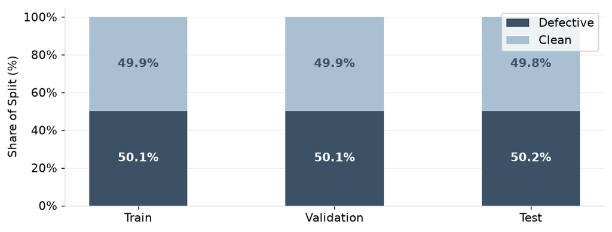

The full feature set is listed below, with each numeric feature's correlation to the target.

| Feature | Type | Corr. with Target |
| --- | --- | --- |
| machine_type | Categorical | - |
| machine_id | Categorical | - |
| shift_code | Categorical | - |
| operator_id | Categorical | - |
| complexity | Categorical | - |
| material_type | Categorical | - |
| supplier | Categorical | - |
| lot_cert_status | Categorical | - |
| requires_welding | Categorical | 0.009 |
| machine_age_years | Numerical | 0.031 |
| std_labor_hrs | Numerical | 0.022 |
| quantity_ordered | Numerical | 0.272 |
| schedule_variance_hrs | Numerical | 0.002 |
| is_bending_shift_b | Interaction | 0.110 |
| is_high_complexity | Interaction | 0.172 |
| is_supplier_c_thin_gauge | Interaction | 0.148 |
| is_lapsed_cert_op | Interaction | 0.251 |

Numeric and Interaction Feature Correlations

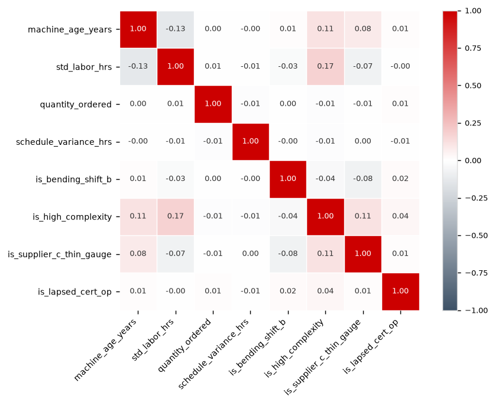

Historical Defect Rate by Categorical Feature

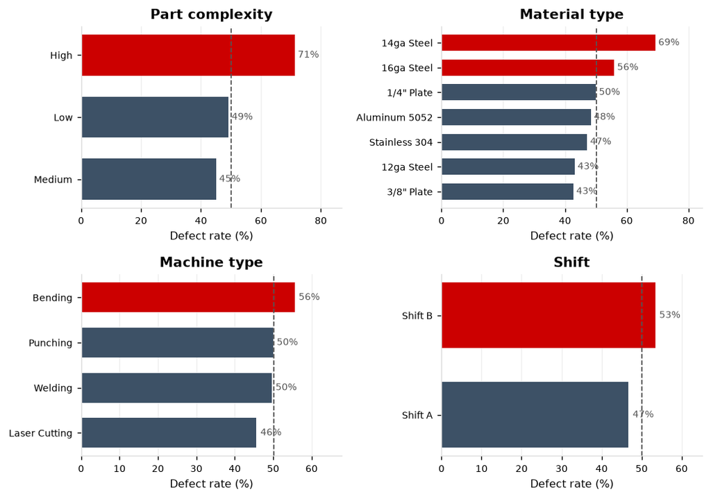

The separation is clear and intuitive. High-complexity parts fail at 71% versus about 45% for medium ones; thin-gauge steel (14 and 16 gauge) runs well above heavier plate; Bending work and Shift B both sit above the average, while Laser Cutting and Shift A sit below it. These are exactly the splits the tree makes, and the interaction features combine them (for example, a high-complexity Bending job on Shift B, or thin-gauge stock from a specific supplier) into the compound conditions that most strongly raise a job's risk score.

Section 3

## Model Selection & Performance

Section 3.1

## Model Selection

Three candidate classifiers, a logistic regression, a random forest, and a gradient-boosted XGBoost model, were tuned with Optuna (150 trials each, validation ROC-AUC objective) and compared on the validation set. XGBoost won on validation ROC-AUC and was registered as the production model, then evaluated once on the held-out test set.

| Model | Val ROC-AUC | Val F1 | Val Precision | Val Recall |
| --- | --- | --- | --- | --- |
| Xgboost ✓ Selected | 0.7450 | 0.6608 | 0.6876 | 0.6360 |
| Logistic Regression | 0.7405 | 0.6568 | 0.6840 | 0.6317 |
| Random Forest | 0.7400 | 0.6486 | 0.6901 | 0.6119 |

Section 3.2

## Model Performance

On the held-out test set the model reaches a **ROC-AUC of 0.76** and an **average precision of 0.78**. The fair yardstick is a no-skill baseline, which scores 0.50 on ROC-AUC and an average precision equal to the 50% defect base rate, so the model adds real discriminative signal above chance. Metrics appear for both the validation set (used for tuning and selection) and the held-out test set, which was touched once.

| Metric | Validation | Test (held-out) |
| --- | --- | --- |
| ROC-AUC | 0.7450 | 0.7618 |
| Avg Precision | 0.7648 | 0.7793 |
| F1 | 0.6608 | 0.6733 |
| Precision | 0.6876 | 0.7011 |
| Recall | 0.6360 | 0.6477 |

Training vs Validation ROC-AUC by Training Set Size

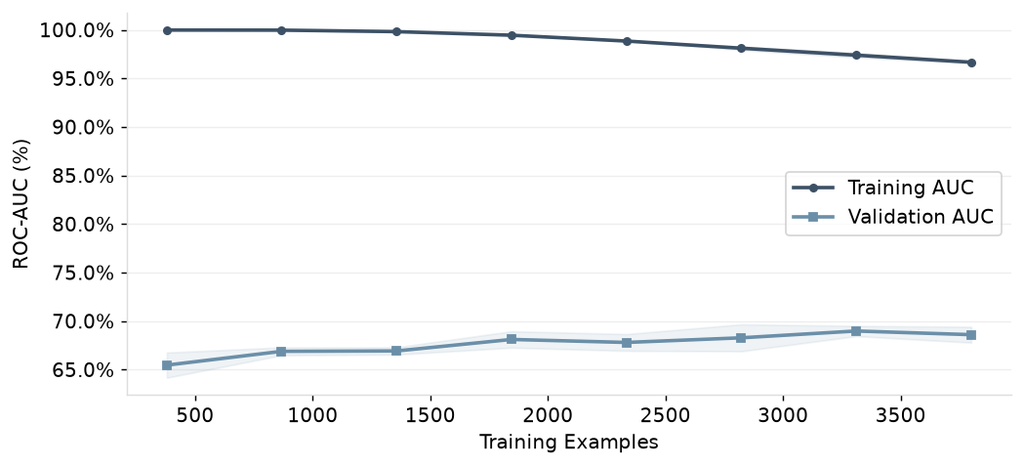

The ROC curve shows the tradeoff between true and false positive rates across every threshold on the held-out test set; the further the curve bows toward the top-left, the better the score ranks defective jobs above clean ones.

ROC Curve, Test Set

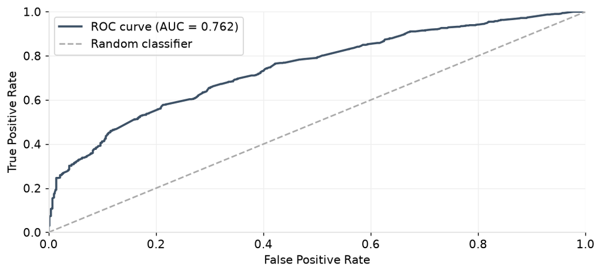

Calibration checks whether the predicted probability can be taken at face value: a well-calibrated model tracks the diagonal, so when it predicts 70%, roughly 70% of those jobs actually produce defects. Points near the diagonal mean the raw scores are usable as probabilities, not only as a ranking.

Predicted Probability vs Actual Defect Rate

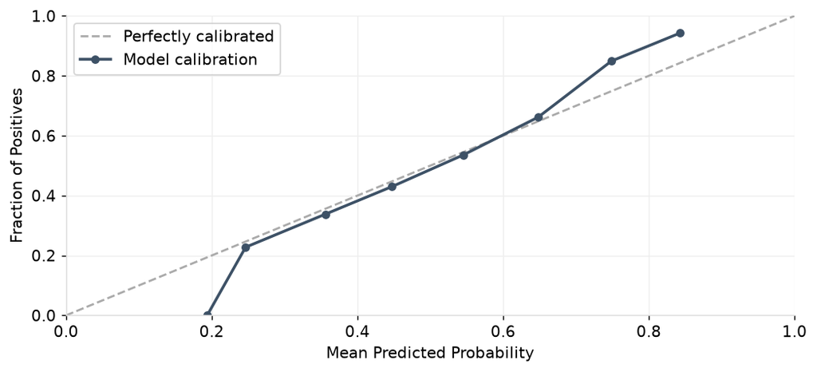

The precision-recall curve shows how tightening the score threshold trades recall for precision; the markers are the High and Medium risk tiers. Moving left along the curve raises precision at the cost of catching fewer defects.

Precision-Recall Curve with Operating Thresholds

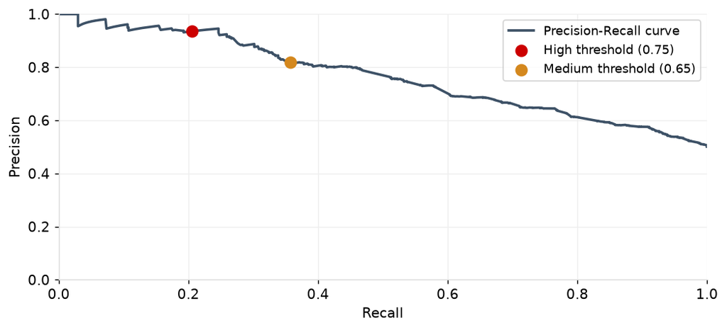

Confusion Matrix, Test Set

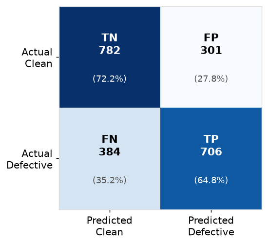

Section 4

## Feature Importance (SHAP)

SHAP (SHapley Additive exPlanations) values measure each feature's average contribution to the model's predictions across the validation set; features with higher mean absolute SHAP values have greater influence on the output. Interaction features appear prominently because they encode the strongest cross-system patterns identified in the diagnostic analysis.

Mean Absolute SHAP Value by Feature

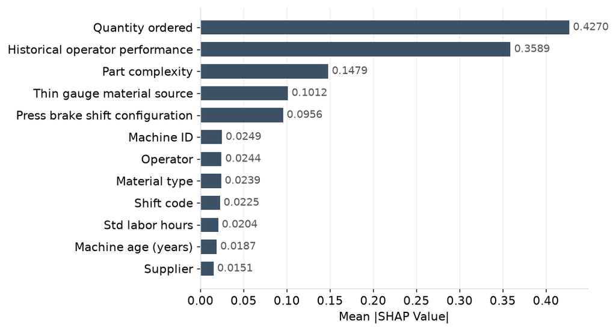

Section 5

Section 6

## Deployment & Operations

How the model runs in production and where its inputs come from.

| Specification | Detail |
| --- | --- |
| Scoring cadence | Monthly batch (`src/scoring.py`); each work order's risk tier and top driver are surfaced inline in the ERP work-order queue |
| Inference latency | A single gradient-boosted model over 17 features; the monthly batch scores all pending work orders in well under a second on commodity hardware |
| Model registry | MLflow Model Registry, defect_risk_scorer v1 (Production); each retrain registers a new version and this report regenerates against it |
| Orchestration | Prefect schedules the monthly scoring and monitoring runs |
| Data lineage | Three source systems (MES machine and production logs, ERP work orders and schedule, QMS inspection outcomes) → dbt staging and marts → features.py → registered model → ERP work-order queue |
| Retraining trigger | Monitoring report rules: High-tier precision below 85%, or the defect rate drifts more than 10 points from the training baseline |